1. Nez R.S - 2022c104100 - 100%
2. Durga S.L - 2022c104051 - 100%
3. Krishnanand Anil - 2022c104004 - 100%

# EDA

```python
import numpy as np
import matplotlib.pyplot as plt
import pandas as pd
from tqdm import tqdm
import seaborn as sn
from pandas.plotting import scatter_matrix
from sklearn.compose import ColumnTransformer
from sklearn.preprocessing import OneHotEncoder
from sklearn.preprocessing import LabelEncoder
from sklearn import model_selection
from sklearn.preprocessing import MinMaxScaler
from sklearn.metrics import classification_report
from sklearn.metrics import confusion_matrix
from sklearn.metrics import accuracy_score
from sklearn.linear_model import LogisticRegression


%matplotlib inline
```

```python
pip install plotly
```

```python
!dir
```

```
 Volume in drive C is Windows
 Volume Serial Number is A8D7-A09B

 Directory of C:\Users\krish\OneDrive\Desktop\Projects\ML\linear regression

10-06-2023  12:29    <DIR>          .
30-05-2023  15:52    <DIR>          ..
10-06-2023  11:54    <DIR>          .ipynb_checkpoints
30-05-2023  15:19           215,609 1_abalone.csv
10-06-2023  12:29         6,141,559 ML_Group4_1_abalone.ipynb
               2 File(s)      6,357,168 bytes
               3 Dir(s)  135,639,445,504 bytes free
```

```python
df = pd.read_csv("1_abalone.csv")
```

```python
df.head()
```

|  | Gender | length | diameter | height | whole_wt | shucked_wt | viscera_wt | shell_wt | rings | age |
| --- | --- | --- | --- | --- | --- | --- | --- | --- | --- | --- |
| 0 | M | 0.455 | 0.365 | 0.095 | 0.5140 | 0.2245 | 0.1010 | 0.150 | 15 | 16.5 |
| 1 | M | 0.350 | 0.265 | 0.090 | 0.2255 | 0.0995 | 0.0485 | 0.070 | 7 | 8.5 |
| 2 | F | 0.530 | 0.420 | 0.135 | 0.6770 | 0.2565 | 0.1415 | 0.210 | 9 | 10.5 |
| 3 | M | 0.440 | 0.365 | 0.125 | 0.5160 | 0.2155 | 0.1140 | 0.155 | 10 | 11.5 |
| 4 | I | 0.330 | 0.255 | 0.080 | 0.2050 | 0.0895 | 0.0395 | 0.055 | 7 | 8.5 |

```python
df.info
```

```
<bound method DataFrame.info of      Gender  length  diameter  height  whole_wt  shucked_wt  viscera_wt  \
0         M   0.455     0.365   0.095    0.5140      0.2245      0.1010
1         M   0.350     0.265   0.090    0.2255      0.0995      0.0485
2         F   0.530     0.420   0.135    0.6770      0.2565      0.1415
3         M   0.440     0.365   0.125    0.5160      0.2155      0.1140
4         I   0.330     0.255   0.080    0.2050      0.0895      0.0395
...     ...     ...       ...     ...       ...         ...         ...
4172      F   0.565     0.450   0.165    0.8870      0.3700      0.2390
4173      M   0.590     0.440   0.135    0.9660      0.4390      0.2145
4174      M   0.600     0.475   0.205    1.1760      0.5255      0.2875
4175      F   0.625     0.485   0.150    1.0945      0.5310      0.2610
4176      M   0.710     0.555   0.195    1.9485      0.9455      0.3765

      shell_wt  rings   age
0       0.1500     15  16.5
1       0.0700      7   8.5
2       0.2100      9  10.5
3       0.1550     10  11.5
4       0.0550      7   8.5
...        ...    ...   ...
4172    0.2490     11  12.5
4173    0.2605     10  11.5
4174    0.3080      9  10.5
4175    0.2960     10  11.5
4176    0.4950     12  13.5

[4177 rows x 10 columns]>
```

```python
df.describe()
```

|  | length | diameter | height | whole_wt | shucked_wt | viscera_wt | shell_wt | rings | age |
| --- | --- | --- | --- | --- | --- | --- | --- | --- | --- |
| count | 4177.000000 | 4177.000000 | 4177.000000 | 4177.000000 | 4177.000000 | 4177.000000 | 4177.000000 | 4177.000000 | 4177.000000 |
| mean | 0.523992 | 0.407881 | 0.139516 | 0.828742 | 0.359367 | 0.180594 | 0.238831 | 9.933684 | 11.433684 |
| std | 0.120093 | 0.099240 | 0.041827 | 0.490389 | 0.221963 | 0.109614 | 0.139203 | 3.224169 | 3.224169 |
| min | 0.075000 | 0.055000 | 0.000000 | 0.002000 | 0.001000 | 0.000500 | 0.001500 | 1.000000 | 2.500000 |
| 25% | 0.450000 | 0.350000 | 0.115000 | 0.441500 | 0.186000 | 0.093500 | 0.130000 | 8.000000 | 9.500000 |
| 50% | 0.545000 | 0.425000 | 0.140000 | 0.799500 | 0.336000 | 0.171000 | 0.234000 | 9.000000 | 10.500000 |
| 75% | 0.615000 | 0.480000 | 0.165000 | 1.153000 | 0.502000 | 0.253000 | 0.329000 | 11.000000 | 12.500000 |
| max | 0.815000 | 0.650000 | 1.130000 | 2.825500 | 1.488000 | 0.760000 | 1.005000 | 29.000000 | 30.500000 |

```python
(df.height ==0).sum()
```

```
2
```

```python
(df.isnull()== 'True').sum()
```

```
Gender        0
length        0
diameter      0
height        0
whole_wt      0
shucked_wt    0
viscera_wt    0
shell_wt      0
rings         0
age           0
dtype: int64
```

```python
df.sort_values(by=['length']).length.unique()
```

```
array([0.075, 0.11 , 0.13 , 0.135, 0.14 , 0.15 , 0.155, 0.16 , 0.165,
       0.17 , 0.175, 0.18 , 0.185, 0.19 , 0.195, 0.2  , 0.205, 0.21 ,
       0.215, 0.22 , 0.225, 0.23 , 0.235, 0.24 , 0.245, 0.25 , 0.255,
       0.26 , 0.265, 0.27 , 0.275, 0.28 , 0.285, 0.29 , 0.295, 0.3  ,
       0.305, 0.31 , 0.315, 0.32 , 0.325, 0.33 , 0.335, 0.34 , 0.345,
       0.35 , 0.355, 0.36 , 0.365, 0.37 , 0.375, 0.38 , 0.385, 0.39 ,
       0.395, 0.4  , 0.405, 0.41 , 0.415, 0.42 , 0.425, 0.43 , 0.435,
       0.44 , 0.445, 0.45 , 0.455, 0.46 , 0.465, 0.47 , 0.475, 0.48 ,
       0.485, 0.49 , 0.495, 0.5  , 0.505, 0.51 , 0.515, 0.52 , 0.525,
       0.53 , 0.535, 0.54 , 0.545, 0.55 , 0.555, 0.56 , 0.565, 0.57 ,
       0.575, 0.58 , 0.585, 0.59 , 0.595, 0.6  , 0.605, 0.61 , 0.615,
       0.62 , 0.625, 0.63 , 0.635, 0.64 , 0.645, 0.65 , 0.655, 0.66 ,
       0.665, 0.67 , 0.675, 0.68 , 0.685, 0.69 , 0.695, 0.7  , 0.705,
       0.71 , 0.715, 0.72 , 0.725, 0.73 , 0.735, 0.74 , 0.745, 0.75 ,
       0.755, 0.76 , 0.765, 0.77 , 0.775, 0.78 , 0.8  , 0.815])
```

```python
df.sort_values(by=['height']).height.unique()
```

```
array([0.   , 0.01 , 0.015, 0.02 , 0.025, 0.03 , 0.035, 0.04 , 0.045,
       0.05 , 0.055, 0.06 , 0.065, 0.07 , 0.075, 0.08 , 0.085, 0.09 ,
       0.095, 0.1  , 0.105, 0.11 , 0.115, 0.12 , 0.125, 0.13 , 0.135,
       0.14 , 0.145, 0.15 , 0.155, 0.16 , 0.165, 0.17 , 0.175, 0.18 ,
       0.185, 0.19 , 0.195, 0.2  , 0.205, 0.21 , 0.215, 0.22 , 0.225,
       0.23 , 0.235, 0.24 , 0.25 , 0.515, 1.13 ])
```

```python
df.sort_values(by=['diameter']).diameter.unique()
```

```
array([0.055, 0.09 , 0.095, 0.1  , 0.105, 0.11 , 0.115, 0.12 , 0.125,
       0.13 , 0.135, 0.14 , 0.145, 0.15 , 0.155, 0.16 , 0.165, 0.17 ,
       0.175, 0.18 , 0.185, 0.19 , 0.195, 0.2  , 0.205, 0.21 , 0.215,
       0.22 , 0.225, 0.23 , 0.235, 0.24 , 0.245, 0.25 , 0.255, 0.26 ,
       0.265, 0.27 , 0.275, 0.28 , 0.285, 0.29 , 0.295, 0.3  , 0.305,
       0.31 , 0.315, 0.32 , 0.325, 0.33 , 0.335, 0.34 , 0.345, 0.35 ,
       0.355, 0.36 , 0.365, 0.37 , 0.375, 0.38 , 0.385, 0.39 , 0.395,
       0.4  , 0.405, 0.41 , 0.415, 0.42 , 0.425, 0.43 , 0.435, 0.44 ,
       0.445, 0.45 , 0.455, 0.46 , 0.465, 0.47 , 0.475, 0.48 , 0.485,
       0.49 , 0.495, 0.5  , 0.505, 0.51 , 0.515, 0.52 , 0.525, 0.53 ,
       0.535, 0.54 , 0.545, 0.55 , 0.555, 0.56 , 0.565, 0.57 , 0.575,
       0.58 , 0.585, 0.59 , 0.595, 0.6  , 0.605, 0.61 , 0.615, 0.62 ,
       0.625, 0.63 , 0.65 ])
```

```python
df[df['height']==0]
```

|  | Gender | length | diameter | height | whole_wt | shucked_wt | viscera_wt | shell_wt | rings | age |
| --- | --- | --- | --- | --- | --- | --- | --- | --- | --- | --- |
| 1257 | I | 0.430 | 0.34 | 0.0 | 0.428 | 0.2065 | 0.0860 | 0.1150 | 8 | 9.5 |
| 3996 | I | 0.315 | 0.23 | 0.0 | 0.134 | 0.0575 | 0.0285 | 0.3505 | 6 | 7.5 |

```python
mean =pd.pivot_table(df, index=['Gender'], aggfunc={'height':np.mean})
mean
```

| Gender | height |
| --- | --- |
| F | 0.158011 |
| I | 0.107996 |
| M | 0.151381 |

```python
df['height'] = df['height'].replace(to_replace=0, value=0.107996)
```

```python
df.describe()
```

|  | length | diameter | height | whole_wt | shucked_wt | viscera_wt | shell_wt | rings | age |
| --- | --- | --- | --- | --- | --- | --- | --- | --- | --- |
| count | 4177.000000 | 4177.000000 | 4177.000000 | 4177.000000 | 4177.000000 | 4177.000000 | 4177.000000 | 4177.000000 | 4177.000000 |
| mean | 0.523992 | 0.407881 | 0.139568 | 0.828742 | 0.359367 | 0.180594 | 0.238831 | 9.933684 | 11.433684 |
| std | 0.120093 | 0.099240 | 0.041721 | 0.490389 | 0.221963 | 0.109614 | 0.139203 | 3.224169 | 3.224169 |
| min | 0.075000 | 0.055000 | 0.010000 | 0.002000 | 0.001000 | 0.000500 | 0.001500 | 1.000000 | 2.500000 |
| 25% | 0.450000 | 0.350000 | 0.115000 | 0.441500 | 0.186000 | 0.093500 | 0.130000 | 8.000000 | 9.500000 |
| 50% | 0.545000 | 0.425000 | 0.140000 | 0.799500 | 0.336000 | 0.171000 | 0.234000 | 9.000000 | 10.500000 |
| 75% | 0.615000 | 0.480000 | 0.165000 | 1.153000 | 0.502000 | 0.253000 | 0.329000 | 11.000000 | 12.500000 |
| max | 0.815000 | 0.650000 | 1.130000 | 2.825500 | 1.488000 | 0.760000 | 1.005000 | 29.000000 | 30.500000 |

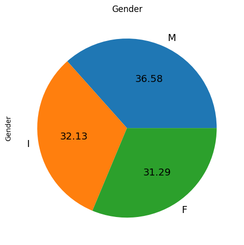

```python
df['Gender'].value_counts(normalize=True).plot(kind='pie',
                                              figsize=(5,5),
                                              title='Gender',
                                              autopct='%.2f',
                                              fontsize=14)
plt.tight_layout()
plt.show()
```

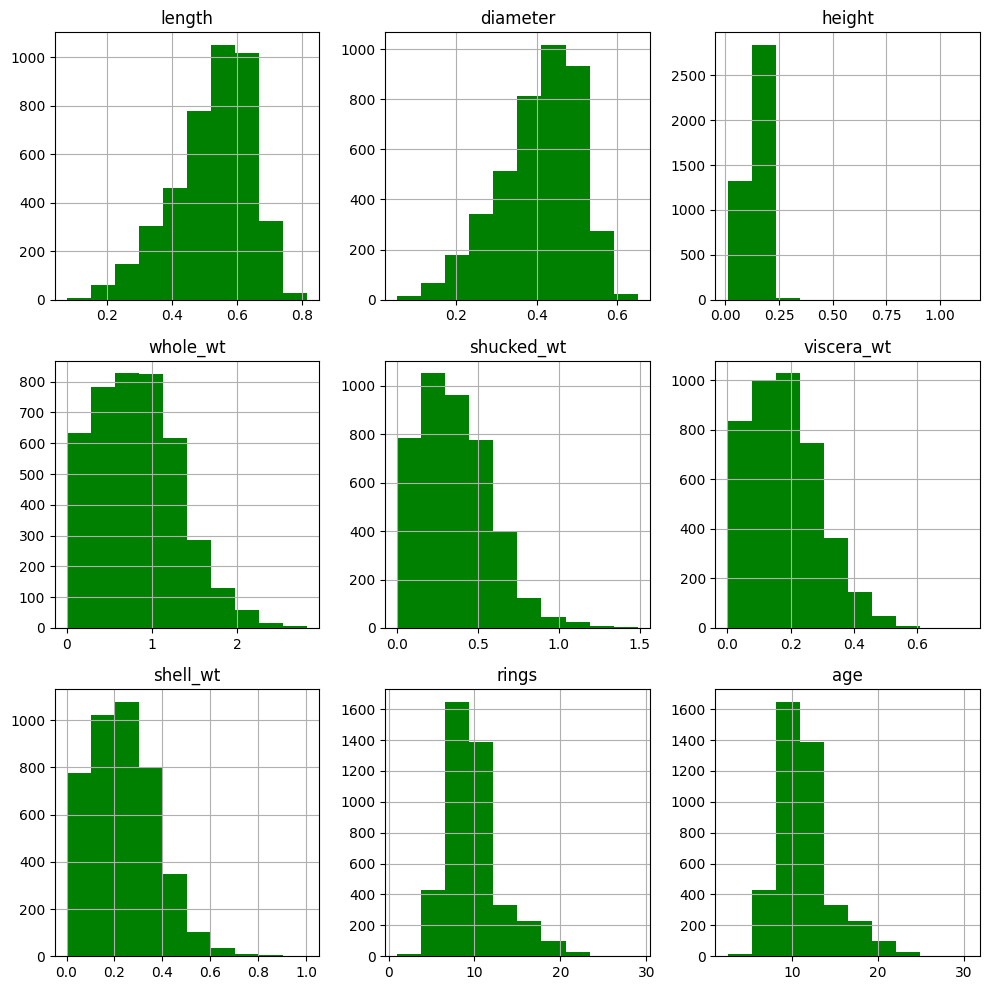

```python
df.hist(figsize=(10,10),
       color='green')
plt.tight_layout()
plt.show()
```

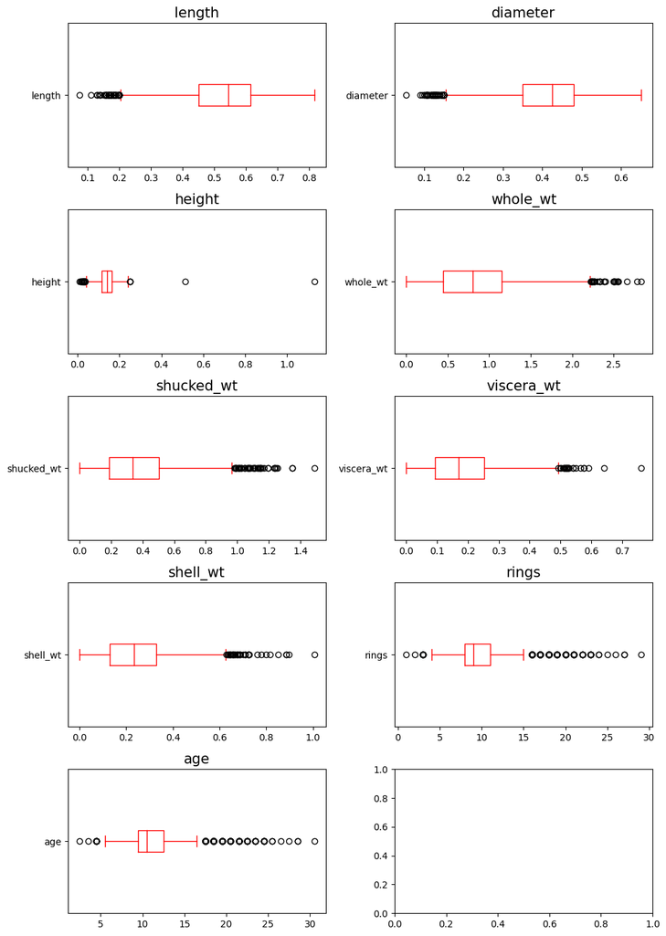

```python
fig, axes =plt.subplots(5,2,figsize=(10,14))
axes = np.ravel(axes)
plt.subplots_adjust(wspace=0.5)
numerics = ['int16', 'int32', 'int64', 'float16', 'float32', 'float64']

for i, c in enumerate(df.select_dtypes(include=numerics)):
    hist= df[c].plot(kind='box', ax=axes[i], title=c, color='red', vert=False)
    axes[i].set_title(c, fontsize=15)

plt.tight_layout()
plt.show()
```

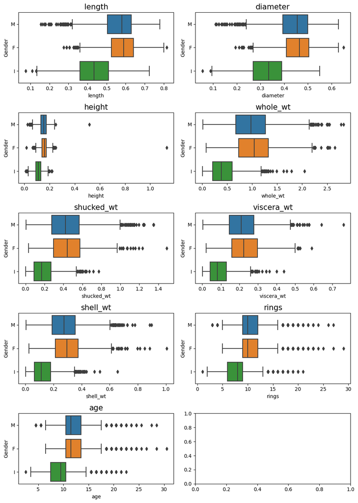

```python
fig, axes =plt.subplots(5,2,figsize=(10,14))
axes= np.ravel(axes)
plt.subplots_adjust(wspace=0.5)
numerics = ['int16', 'int32', 'int64', 'float16', 'float32', 'float64']


for i, c in enumerate(df.select_dtypes(include=numerics)):
    plt.figure
    sn.boxplot(x=df[c], y=df["Gender"],ax=axes[i])
    axes[i].set_title(c, fontsize=15)

plt.tight_layout()
plt.show()
```

# Data pre processing

```python
#handling outliers
Q1 = df.quantile(0.25)
Q3 = df.quantile(0.75)
IQR = Q3-Q1
print(IQR)
```

```
length        0.1650
diameter      0.1300
height        0.0500
whole_wt      0.7115
shucked_wt    0.3160
viscera_wt    0.1595
shell_wt      0.1990
rings         3.0000
age           3.0000
dtype: float64
```

```python
df = df[~((df < (Q1 - 1.5 * IQR)) | (df > (Q3 + 1.5 * IQR))).any(axis=1)]
```

```python
df.count()
```

```
Gender        3783
length        3783
diameter      3783
height        3783
whole_wt      3783
shucked_wt    3783
viscera_wt    3783
shell_wt      3783
rings         3783
age           3783
dtype: int64
```

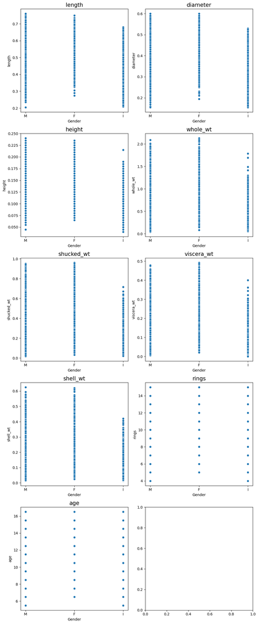

```python
fig, axes =plt.subplots(5,2,figsize=(10,24))
plt.subplots_adjust(wspace=0.5)
numerics = ['int16', 'int32', 'int64', 'float16', 'float32', 'float64']

j=0
k=0
for i, c in enumerate(df.select_dtypes(include=numerics)):
    plt.figure
    sn.scatterplot(y=df[c], x=df["Gender"],ax=axes[j,k])
    axes[j,k].set_title(c, fontsize=15)
    if i%2!=0 :
        j+=1
        k=0
    else:
        k=1

plt.tight_layout()
plt.show()
```

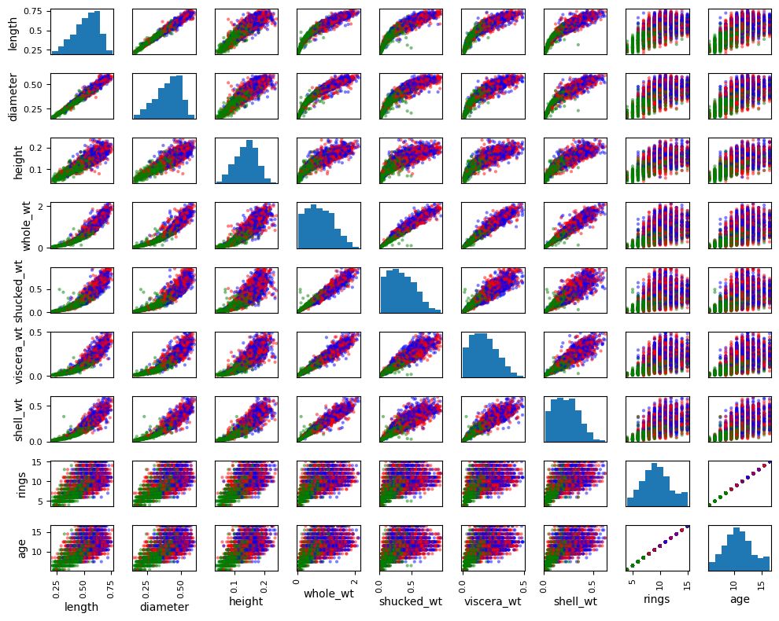

```python
colors = {'M':'red', 'F':'blue', 'I':'green'}
scatter_matrix(df,c=df['Gender'].map(colors),figsize=(10,8))
plt.tight_layout()
```

```python
import plotly.express as px

fig = px.scatter_3d(df, x = 'shell_wt',
                    y = 'shucked_wt',
                    z = 'age',
                    color = 'Gender')

fig.show()
```

[interactive chart not shown]

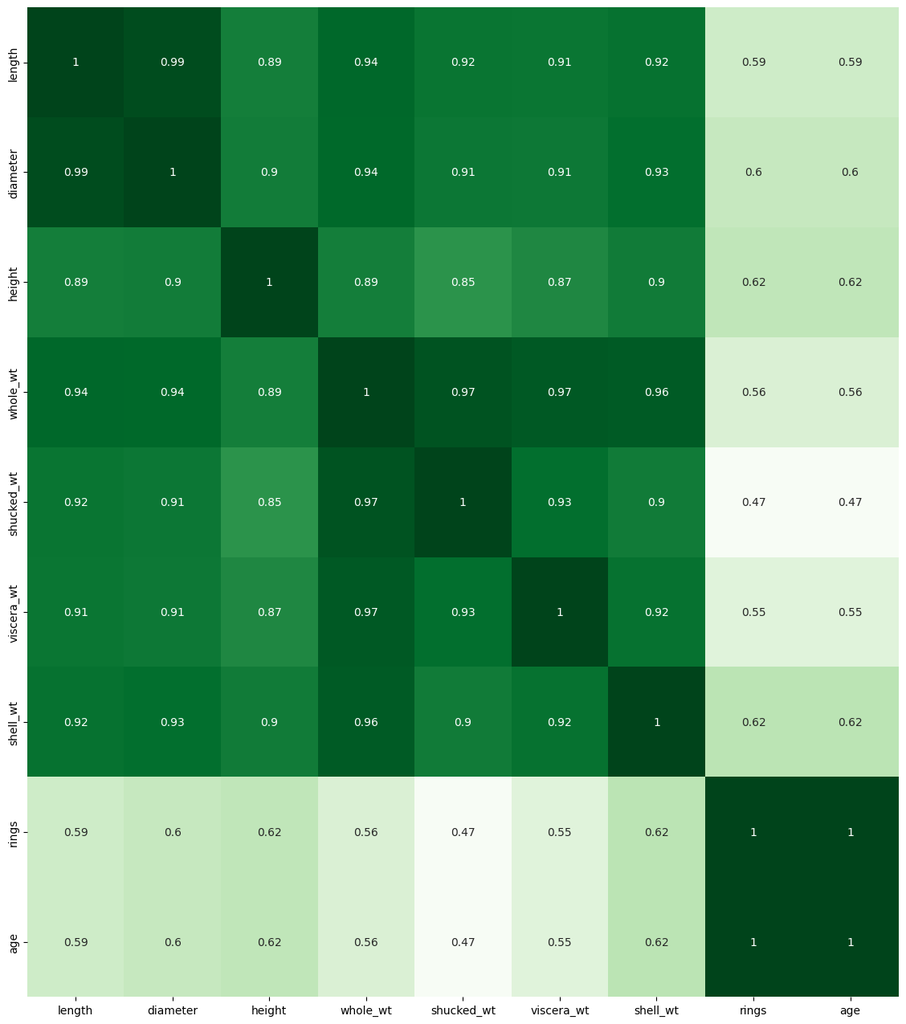

```python
plt.figure(figsize=(14,16))
sn.heatmap(df.corr('pearson'), annot=True, cbar=False, cmap='Greens')

plt.show()
```

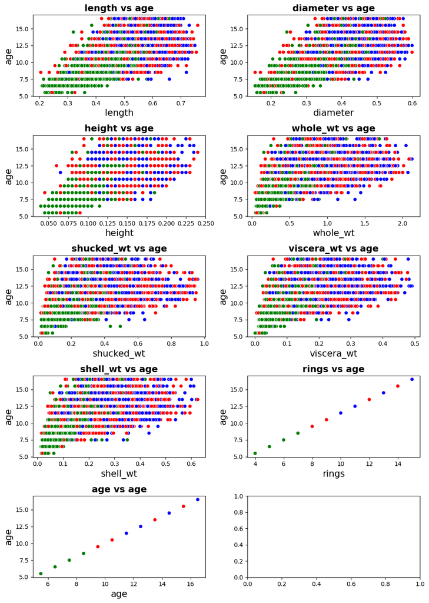

```python
fig, axes =plt.subplots(5,2,figsize=(10,14))
axes= np.ravel(axes)
plt.subplots_adjust(wspace=0.5)
numerics = ['int16', 'int32', 'int64', 'float16', 'float32', 'float64']

colors = {'M':'red', 'F':'blue', 'I':'green'}
for i, c in enumerate(df.select_dtypes(include=numerics)):
    plt.figure
    _ = sn.scatterplot(x=df[c], y=df["age"],c=df['Gender'].map(colors),ax=axes[i])
    axes[i].set_title(f"{c} vs age", fontsize=15, fontweight='bold')
    axes[i].set_xlabel(c, fontsize=15)
    axes[i].set_ylabel('age', fontsize=15)

plt.tight_layout()
plt.show()
```

from the above EDA we can understand the following:

1. no of rings and age are highly correlated.
2. In the case of gender we can see that I is clustered together with greate distinction than other genders
3. Outlayers were removed using df[~((df < (Q1 - 1.5 *IQR)) | (df > (Q3 + 1.5* IQR))).any(axis=1)] as part of cleaning data

   Gender was taken as target because we can see distinction between I and other gender groups

```python
features = df.drop('rings', axis=1).drop('Gender', axis=1)
target = df['Gender']
```

1. we can see rings and age is highly correlated so we have chose to drop rings as a part of feature reduction

```python
labelencoder = LabelEncoder()
# Assigning numerical values and storing in another column
target = labelencoder.fit_transform(target)
```

data preprocessing - encoding is performed

```python
x=features.values
y=target
```

```python
X_trainval, X_test, Y_trainval, Y_test = model_selection.train_test_split(x, y, random_state=0)

X_train, X_valid, Y_train, Y_valid = model_selection.train_test_split(X_trainval, Y_trainval, random_state=1)

print("training set: {} validation set: {} test set: {}".format(X_train.shape,X_valid.shape,X_test.shape))
```

```
training set: (2127, 8) validation set: (710, 8) test set: (946, 8)
```

```python
scaler = MinMaxScaler()
scaler.fit(X_trainval)
X_trainval_scaled = scaler.transform(X_trainval)
X_test_scaled =scaler.transform(X_test)
X_train_scaled = scaler.transform(X_train)
X_valid_scaled = scaler.transform(X_valid)
```

```python
seed = 6
scoring = 'accuracy'
```

```python
Y_train
```

```
array([0, 1, 2, ..., 2, 1, 1])
```

```python
best_score = 0

for C in [0.001, 0.01, 0.1, 1, 10, 100]:
    for solver in ['newton-cg', 'sag', 'saga', 'lbfgs']:
        logreg = LogisticRegression(max_iter=1000, multi_class='multinomial',
                                   C=C, solver=solver, penalty='l2')
        logreg.fit(X_train_scaled, Y_train)
        score = logreg.score(X_valid_scaled, Y_valid)
        if score > best_score:
            best_score = score
            best_params = {'C':C, 'solver':solver}
logreg = LogisticRegression(**best_params)
logreg.fit(X_trainval_scaled, Y_trainval)
train_score = logreg.score(X_trainval_scaled, Y_trainval)
test_score = logreg.score(X_test_scaled, Y_test)

print("Best score on val set: {:.2f}".format(best_score))
print("Best parameters: ", best_params)
print("Train test score with best parameters: {:.2f}".format(train_score))
print("Test set score with best parameters: {:2f}".format(test_score))
```

```
Best score on val set: 0.57
Best parameters:  {'C': 100, 'solver': 'newton-cg'}
Train test score with best parameters: 0.57
Test set score with best parameters: 0.553911
```

```python
model = LogisticRegression(max_iter=1000, multi_class='multinomial', C=100,
                          solver='newton-cg', penalty='l2')
model.fit(X_trainval_scaled, Y_trainval)
```

```
LogisticRegression(C=100, max_iter=1000, multi_class='multinomial',
                   solver='newton-cg')
```

```python
Y_pred = model.predict(X_test_scaled)
```

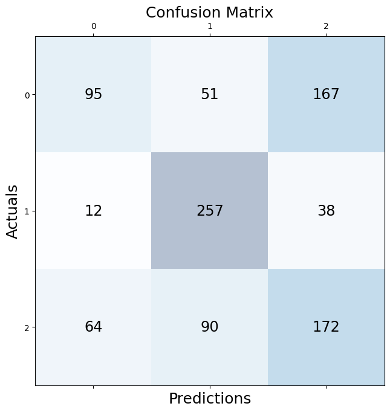

```python
from sklearn.metrics import confusion_matrix
conf_matrix = confusion_matrix(y_true=Y_test, y_pred=Y_pred)
fig, ax = plt.subplots(figsize=(7.5, 7.5))
ax.matshow(conf_matrix, cmap=plt.cm.Blues, alpha=0.3)
for i in range(conf_matrix.shape[0]):
    for j in range(conf_matrix.shape[1]):
        ax.text(x=j, y=i,s=conf_matrix[i, j], va='center', ha='center', size='xx-large')

plt.xlabel('Predictions', fontsize=18)
plt.ylabel('Actuals', fontsize=18)
plt.title('Confusion Matrix', fontsize=18)
plt.show()
```

# 95+257+172/946 % = 55.3%

1. we have used logistic regression with c values as [0.001, 0.01, 0.1, 1, 10, 100] which controls regularization, we found 100 to be the most accurate.
2. different solvers were used ['newton-cg', 'sag', 'saga', 'lbfgs'] out of which newton-cg has best accuracy.
3. max iterations were taken as 1000 and multi_class as 'multinomial' as there is more than two classes and penalty as l2 which takes sum of squares.
4. observations - we can see we have 55.3% accuracy which is low indicating the model requires more finetuning.

# linear Regression

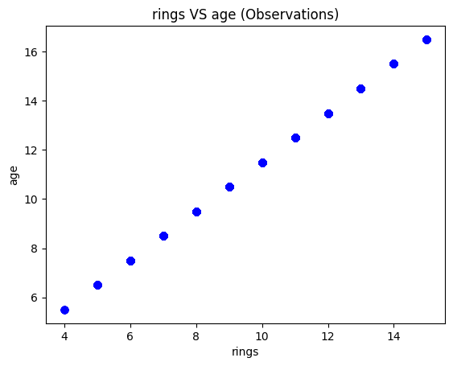

```python
# Visualize the dataset

plt.scatter(df.rings, df.age, color='blue')
plt.title('rings VS age (Observations)')
plt.xlabel('rings')
plt.ylabel('age')
plt.show()
```

```python
X = df.rings # copy all columns excluding last column
Y = df.age   # copy the last column only
```

1. as we can see rings are highly corelated with age we have only taken rings and dropped other columns.
2. we have already cleaned data using outliers removal.

```python
X_train, X_test, Y_train, Y_test = model_selection.train_test_split(X, Y,test_size=0.2, random_state=1)

print("training set: {} validation set: {} test set: {}".format(X_train.shape,X_valid.shape,X_test.shape))
```

```
training set: (3026,) validation set: (710, 8) test set: (757,)
```

```python
# Build the model

theta1 = 0
theta0 = 0

alpha = 0.0001  # Learning Rate
epochs = 1000  # Number of iterations to perform gradient descent

m = float(len(X_train)) # Number of elements in X

cost_history = []
# Performing Gradient Descent
for i in range(epochs):
    Y_pred = theta1 * X_train + theta0
    temp1 = (-1/m) * sum(X_train * (Y_train - Y_pred))
    temp0 = (-1/m) * sum(Y_train - Y_pred)
    theta1 = theta1 - alpha * temp1
    theta0 = theta0 - alpha * temp0
    cost = (1/2*m) * sum((Y_train - Y_pred)**2)
    cost_history.append(cost)
```

```python
# The coefficients

# print the parameter theta1
print('Theta1 = ', theta1)
# print the parameter theta0
print('Theta0 = ', theta0)
```

```
Theta1 =  1.1380211079730091
Theta0 =  0.12197891506586649
```

```python
# Predict the values for the given X
Y_pred = theta1 * X_test + theta0
```

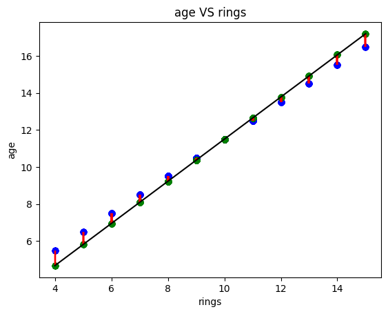

```python
# Visualize the dataset and plot the residuals

fig, ax = plt.subplots()

ax.scatter(X_test, Y_test, color='blue')       # observed values
ax.scatter(X_test, Y_pred, color='green') # predicted values
ax.vlines(X_test,Y_test, Y_pred, color='red')  # residual lines
plt.plot([min(X_test), max(X_test)], [min(Y_pred), max(Y_pred)], color='black')  # regression line

plt.title('age VS rings')
plt.xlabel('rings')
plt.ylabel('age')
plt.show()
```

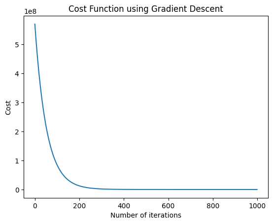

```python
# plot the cost function

plt.plot(cost_history)
plt.title('Cost Function using Gradient Descent')
plt.xlabel("Number of iterations")
plt.ylabel("Cost")
plt.show()
```

```python
from sklearn.metrics import mean_squared_error, r2_score

# The mean squared error
print("Mean squared error = %.2f" % mean_squared_error(Y_test, Y_pred))

# Explained variance score: 1 is perfect prediction
print('Variance score = %.2f' % r2_score(Y_test, Y_pred))
```

```
Mean squared error = 0.11
Variance score = 0.98
```